# R Coding Cheatsheet

#### Slice

slice() selects specific rows

```r
as.data.frame(state.x77) %>%
  slice(4:7) # rows 4 through 7
```

```
##             Population Income Illiteracy Life Exp Murder HS Grad Frost   Area
## Arkansas          2110   3378        1.9    70.66   10.1    39.9    65  51945
## California       21198   5114        1.1    71.71   10.3    62.6    20 156361
## Colorado          2541   4884        0.7    72.06    6.8    63.9   166 103766
## Connecticut       3100   5348        1.1    72.48    3.1    56.0   139   4862
```

#### Pivot_longer and pivot_wider

Pivot refers to reshaping the dataset from a long format or wide format, most helpful when trying to make a line plot with multiple lines.

pivot_longer(cols=c(*names of columns that you want to be longways now),*values_to = *“name of column you want the values to go into”*, names_to=*“name of column you want the list of column names to go to”*)

```r
head(bind_cols(state_name = state.name,state.x77),10) # what the data looks like before
```

```
## # A tibble: 10 × 9
##    state_name  Population Income Illiteracy `Life Exp` Murder `HS Grad` Frost
##    <chr>            <dbl>  <dbl>      <dbl>      <dbl>  <dbl>     <dbl> <dbl>
##  1 Alabama           3615   3624        2.1       69.0   15.1      41.3    20
##  2 Alaska             365   6315        1.5       69.3   11.3      66.7   152
##  3 Arizona           2212   4530        1.8       70.6    7.8      58.1    15
##  4 Arkansas          2110   3378        1.9       70.7   10.1      39.9    65
##  5 California       21198   5114        1.1       71.7   10.3      62.6    20
##  6 Colorado          2541   4884        0.7       72.1    6.8      63.9   166
##  7 Connecticut       3100   5348        1.1       72.5    3.1      56     139
##  8 Delaware           579   4809        0.9       70.1    6.2      54.6   103
##  9 Florida           8277   4815        1.3       70.7   10.7      52.6    11
## 10 Georgia           4931   4091        2         68.5   13.9      40.6    60
## # ℹ 1 more variable: Area <dbl>
```

```r
bind_cols(state_name = state.name,state.x77) %>%
  pivot_longer(cols=Population:Area,values_to="value",names_to="old_column_name") # the column in the cols= is selecting all columns between Population and Area
```

```
## # A tibble: 400 × 3
##    state_name old_column_name   value
##    <chr>      <chr>             <dbl>
##  1 Alabama    Population       3615
##  2 Alabama    Income           3624
##  3 Alabama    Illiteracy          2.1
##  4 Alabama    Life Exp           69.0
##  5 Alabama    Murder             15.1
##  6 Alabama    HS Grad            41.3
##  7 Alabama    Frost              20
##  8 Alabama    Area            50708
##  9 Alaska     Population        365
## 10 Alaska     Income           6315
## # ℹ 390 more rows
```

#### Join

If you want to merge a dataset, you give two data frames, and then in the by= argument, put the names the column in the datasets you are matching on. Left_join will keep all observations in the first dataset listed, merging the second dataframe onto it.

left_join(*dataframe1,dataframe2,*by=c(“column in df1”=“column in df2”))

### GGPlot

ggplot2 is the library that allows you to make charts more pretty than you can in base R code.

When making lines of code in ggplot, each line needs to be followed by “+” instead of a pipe

```r
example_df = data.frame(datasets::WorldPhones,year=c(1951,1956:1961)) %>% pivot_longer(cols="N.Amer":"Mid.Amer")
# number of phones in each region over time
```

#### Line plot

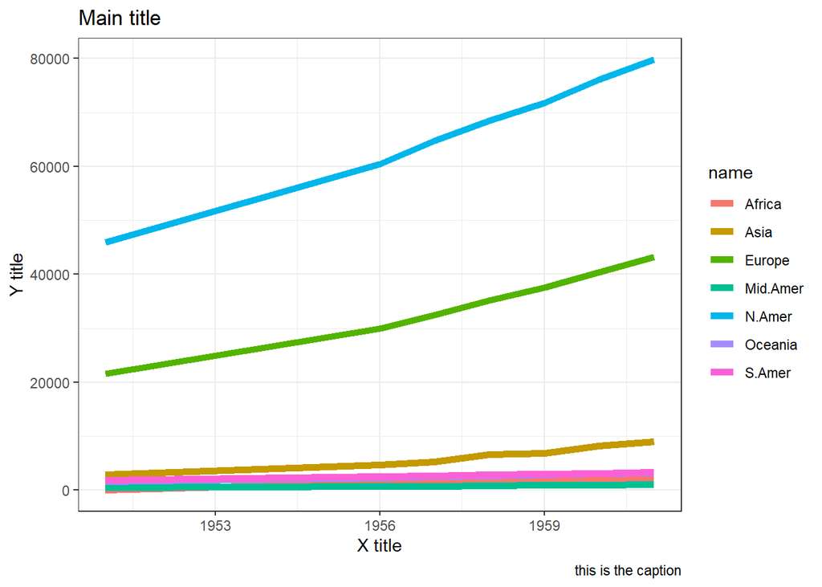

```r
ggplot(example_df,aes(x=year,y=value,color=name)) +
  geom_line(size=2) +
  theme_bw() +
  labs(x="X title",y="Y title",title="Main title",caption="this is the caption")
```

#### Bar chart

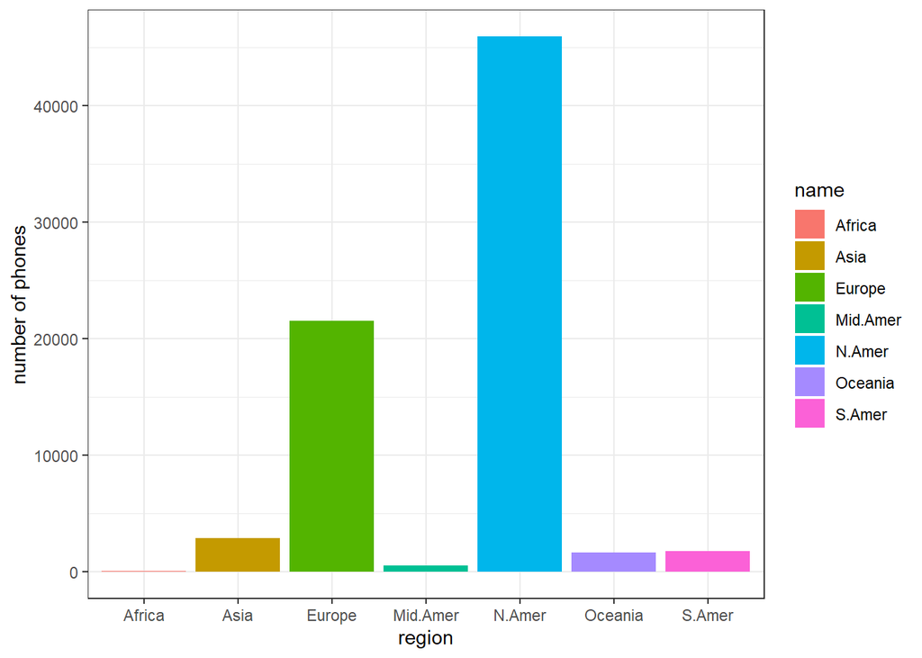

```r
ggplot(example_df %>% filter(year==1951),aes(x=name,y=value,fill=name)) + # when making bar chart, fill is what controls the color
  geom_bar(stat="identity") + # tells R to use the value as given, not some other summary statistic
  theme_bw() +
  labs(x="region",y="number of phones")
```

#### Faceting

You can make the same chart for different groups, kind of like how we use group_by() in dplyr

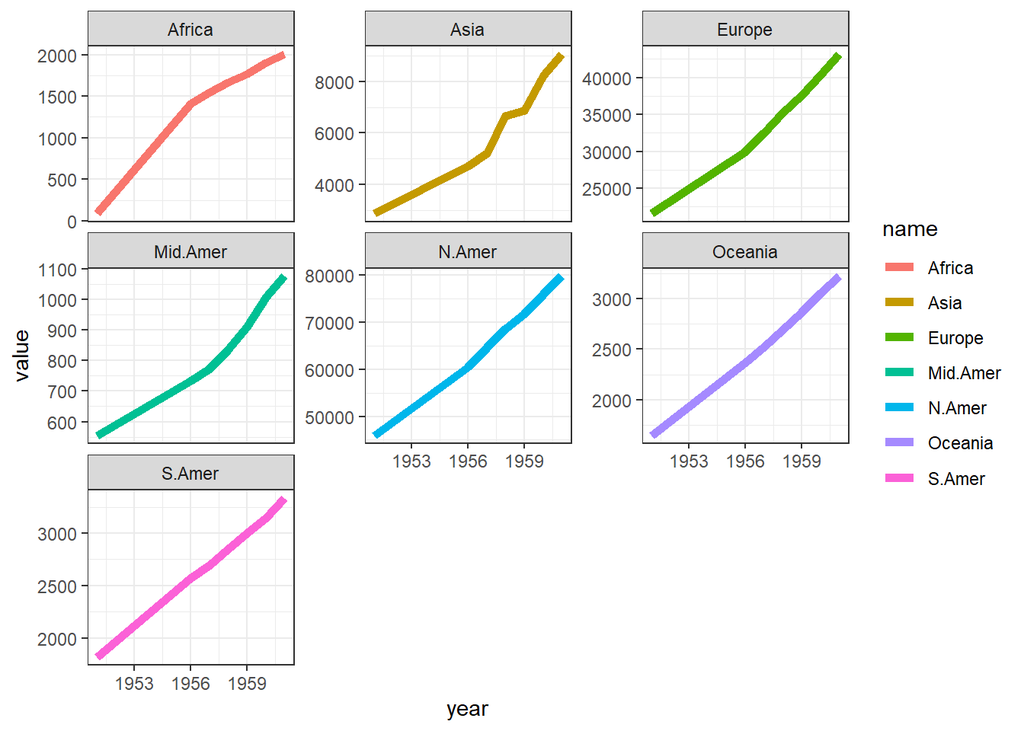

```r
ggplot(example_df,aes(x=year,y=value,color=name)) +
  geom_line(size=2) +
  theme_bw() +
  facet_wrap(~name,scales="free_y") # free_y for scales means each square gets its own scale on the y-axis, instead of all being the same
```

#### Scatter plot and getting a line of best fit

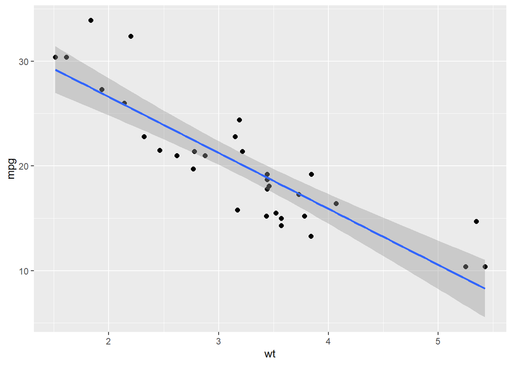

```r
# weight and mpg of cars
ggplot(mtcars,aes(x=wt,y=mpg)) +
  geom_point(size=2) +
  geom_smooth(method="lm")
```

### For-loops basics

a for-loop lets you run the same piece of code, replacing one variable for each element in a list. For example, the following code prints out a given number for each of 1 through 5:

```r
for(i in 1:5){

  print(i)

}
```

```
## [1] 1
## [1] 2
## [1] 3
## [1] 4
## [1] 5
```

The general syntax is for(x in *a list)*{ *code here* }

### If else statements

```r
x = 2

if(x%%2==0){

  print("This is even")

} else{

  print("This is odd")

}
```

```
## [1] "This is even"
```

```r
 for(num in c(1,4,6,2,3,5,10,15,389280,981298093)){

    if(num%%2==0){

  print(paste0(num," is even"))

} else{

  print(paste0(num," is odd"))

}
 }
```

```
## [1] "1 is odd"
## [1] "4 is even"
## [1] "6 is even"
## [1] "2 is even"
## [1] "3 is odd"
## [1] "5 is odd"
## [1] "10 is even"
## [1] "15 is odd"
## [1] "389280 is even"
## [1] "981298093 is odd"
```

Some contexts where you might be using loops is when reading in a bunch of files at once, or doing things state by state. See in the group exercise HTML file in the Week 4 folder on github for an explanation of when this might be relevant.

### Miscellaneous functions

length() will tell you how long a vector is

nrow(df) and ncol(df) will give you numbers of rows and columns in a data frame

unique() will return the unique values in a vector, removing the duplicates

table() will return a frequency table for each of the distinct values in a vector

```r
table(c(1:5,4:20,10:30))
```

```
##
##  1  2  3  4  5  6  7  8  9 10 11 12 13 14 15 16 17 18 19 20 21 22 23 24 25 26
##  1  1  1  2  2  1  1  1  1  2  2  2  2  2  2  2  2  2  2  2  1  1  1  1  1  1
## 27 28 29 30
##  1  1  1  1
```

save.image(filename.RData) saves the entire environment (all objects) you have open to a file called an RData file.

write.csv(dataframe,filename) writes a data frame to a csv